# Marketing Campaign analysis with pandas

```python
import numpy as np
import pandas as pd
import matplotlib.pyplot as plt
```

```python
marketing = pd.read_csv('marketing.csv')
marketing.head(5)
```

|  | user_id | date_served | marketing_channel | variant | converted | language_displayed | language_preferred | age_group | date_subscribed | date_canceled | subscribing_channel | is_retained |
| --- | --- | --- | --- | --- | --- | --- | --- | --- | --- | --- | --- | --- |
| 0 | a100000029 | 1/1/18 | House Ads | personalization | True | English | English | 0-18 years | 1/1/18 | NaN | House Ads | True |
| 1 | a100000030 | 1/1/18 | House Ads | personalization | True | English | English | 19-24 years | 1/1/18 | NaN | House Ads | True |
| 2 | a100000031 | 1/1/18 | House Ads | personalization | True | English | English | 24-30 years | 1/1/18 | NaN | House Ads | True |
| 3 | a100000032 | 1/1/18 | House Ads | personalization | True | English | English | 30-36 years | 1/1/18 | NaN | House Ads | True |
| 4 | a100000033 | 1/1/18 | House Ads | personalization | True | English | English | 36-45 years | 1/1/18 | NaN | House Ads | True |

```python
# Convert is_retained to a boolean
marketing['is_retained'] = marketing['is_retained'].astype('bool')

# Check the data type of is_retained, again
print(marketing['is_retained'].dtype)
```

```
bool
```

```python
# Mapping for channels
channel_dict = {"House Ads": 1, "Instagram": 2,
                "Facebook": 3, "Email": 4, "Push": 5}

# Map the channel to a channel code
marketing['channel_code'] = marketing['subscribing_channel'].map(channel_dict)


# Add the new column is_correct_lang
marketing['is_correct_lang'] = np.where(
    marketing['language_preferred'] == marketing['language_displayed'],
    'Yes',
    'No'
)
```

```python
# Import marketing.csv with date columns
marketing = pd.read_csv('marketing.csv',
                        parse_dates = ['date_served', 'date_subscribed', 'date_canceled'])

# Add a DoW column
marketing['DoW'] = marketing['date_subscribed'].dt.dayofweek
```

```python
# Group by date_served and count number of unique user_id's
daily_users = marketing.groupby(['date_served'])['user_id'].nunique()
daily_users.head()
```

```
date_served
2018-01-01    362
2018-01-02    374
2018-01-03    348
2018-01-04    323
2018-01-05    319
Name: user_id, dtype: int64
```

# Overall Conversion Rate

Number of people who convert/ Total number of people who we market to

```python
# Calculate the number of people we marketed to
total = marketing['user_id'].nunique()
total

# Calculate the number of people who subscribed
subscribers = marketing[marketing['converted'] == True]['user_id'].nunique()
subscribers

# Calculate the conversion rate
conversion_rate = subscribers/total
print('Overall Conversion rate:', round(conversion_rate*100, 2), "%")
```

```
Overall Conversion rate: 13.89 %
```

# Overall Retention Rate

```python
# Calculate the number of subscribers
total_subscribers =  marketing[marketing['converted'] == True]['user_id'].nunique()

# Calculate the number of people who remained subscribed
retained = marketing[marketing['is_retained'] == True]['user_id'].nunique()
marketing['is_retained'].unique()

# Calculate the retention rate
retention_rate = retained/total_subscribers
print('Overall Retention rate:', round(retention_rate*100, 2), "%")
```

```
Overall Retention rate: 66.8 %
```

# Conversion Rate by Language Spoken

```python
# Isolate english speakers
english_speakers = marketing[marketing['language_displayed'] == 'English']

# Calculate the total number of english speaking users
total = english_speakers['user_id'].nunique()

# Calculate the number of english speakers who converted
subscribers = english_speakers[english_speakers['converted'] == True]\
                            ['user_id'].nunique()

# Calculate conversion rate
conversion_rate = subscribers/total
print('English speaker conversion rate:',  round(conversion_rate*100,2), '%')
```

```
English speaker conversion rate: 12.92 %
```

```python
# Group by language_displayed and count unique users
total = marketing.groupby(['language_displayed'])\
                                  ['user_id'].nunique()

# Group by language_displayed and count unique conversions
subscribers = marketing[marketing['converted'] == True]\
                       .groupby(['language_displayed'])\
                       ['user_id'].nunique()

# Calculate the conversion rate for all languages
language_conversion_rate = subscribers/total
print('Conversion rate per language:',language_conversion_rate)
```

```
Conversion rate per language: language_displayed
Arabic     0.500000
English    0.129167
German     0.716216
Spanish    0.200000
Name: user_id, dtype: float64
```

```python
print('Conversion rate per language:', round(language_conversion_rate*100,2), '%')
```

```
Conversion rate per language: language_displayed
Arabic     50.00
English    12.92
German     71.62
Spanish    20.00
Name: user_id, dtype: float64 %
```

German speakers have the highest conversion rate.

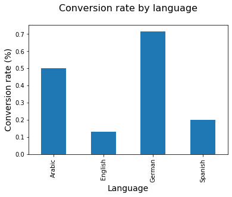

```python
language_conversion_rate.plot(kind='bar')
plt.title('Conversion rate by language\n', size = 16)
plt.xlabel('Language', size = 14)
plt.ylabel('Conversion rate (%)', size = 14)

plt.show()
```

# Daily Conversion Rate

```python
# Group by date_served and count unique users #Conversion rate per day
marketing.head()
marketing['date_served'].unique()

total = marketing.groupby(['date_served'])['user_id'].nunique()
total.head()

# Group by date_served and count unique converted users
subscribers = marketing[marketing['converted'] == True].groupby(['date_served'])['user_id'].nunique()
subscribers.head()

# Calculate the conversion rate per day
daily_conversion_rate = subscribers/total
print(daily_conversion_rate)
```

```
date_served
2018-01-01    0.099448
2018-01-02    0.098930
2018-01-03    0.103448
2018-01-04    0.108359
2018-01-05    0.125392
2018-01-06    0.113636
2018-01-07    0.141818
2018-01-08    0.115385
2018-01-09    0.125000
2018-01-10    0.118694
2018-01-11    0.080645
2018-01-12    0.076412
2018-01-13    0.084967
2018-01-14    0.085246
2018-01-15    0.113429
2018-01-16    0.255155
2018-01-17    0.219512
2018-01-18    0.091195
2018-01-19    0.059016
2018-01-20    0.067524
2018-01-21    0.087336
2018-01-22    0.123596
2018-01-23    0.122093
2018-01-24    0.115789
2018-01-25    0.125000
2018-01-26    0.090090
2018-01-27    0.065625
2018-01-28    0.062500
2018-01-29    0.059561
2018-01-30    0.066246
2018-01-31    0.052941
Name: user_id, dtype: float64
```

```python
# Reset index to turn the results into a DataFrame
daily_conversion_rate = pd.DataFrame(daily_conversion_rate.reset_index(0))
daily_conversion_rate.head()
# Rename columns
daily_conversion_rate.columns = ['date_served', 'conversion_rate']
daily_conversion_rate
```

|  | date_served | conversion_rate |
| --- | --- | --- |
| 0 | 2018-01-01 | 0.099448 |
| 1 | 2018-01-02 | 0.098930 |
| 2 | 2018-01-03 | 0.103448 |
| 3 | 2018-01-04 | 0.108359 |
| 4 | 2018-01-05 | 0.125392 |
| 5 | 2018-01-06 | 0.113636 |
| 6 | 2018-01-07 | 0.141818 |
| 7 | 2018-01-08 | 0.115385 |
| 8 | 2018-01-09 | 0.125000 |
| 9 | 2018-01-10 | 0.118694 |
| 10 | 2018-01-11 | 0.080645 |
| 11 | 2018-01-12 | 0.076412 |
| 12 | 2018-01-13 | 0.084967 |
| 13 | 2018-01-14 | 0.085246 |
| 14 | 2018-01-15 | 0.113429 |
| 15 | 2018-01-16 | 0.255155 |
| 16 | 2018-01-17 | 0.219512 |
| 17 | 2018-01-18 | 0.091195 |
| 18 | 2018-01-19 | 0.059016 |
| 19 | 2018-01-20 | 0.067524 |
| 20 | 2018-01-21 | 0.087336 |
| 21 | 2018-01-22 | 0.123596 |
| 22 | 2018-01-23 | 0.122093 |
| 23 | 2018-01-24 | 0.115789 |
| 24 | 2018-01-25 | 0.125000 |
| 25 | 2018-01-26 | 0.090090 |
| 26 | 2018-01-27 | 0.065625 |
| 27 | 2018-01-28 | 0.062500 |
| 28 | 2018-01-29 | 0.059561 |
| 29 | 2018-01-30 | 0.066246 |
| 30 | 2018-01-31 | 0.052941 |

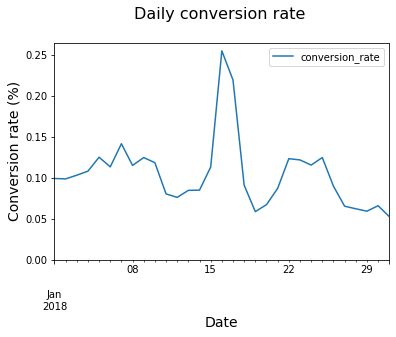

```python
daily_conversion_rate.plot('date_served','conversion_rate')

plt.title('Daily conversion rate \n', size = 16)
plt.ylabel('Conversion rate (%)', size = 14)
plt.xlabel('Date', size = 14)
# Set the y-axis to begin at 0
plt.ylim(0)
# Display the plot
plt.show()
```

# Marketing channels across age groups

```python
channel_age = marketing.groupby(['marketing_channel', 'age_group'])['user_id'].count()

# Unstack channel_age and transform it into a DataFrame
channel_age_df = pd.DataFrame(channel_age.unstack(level = 1))
channel_age_df
```

| age_group marketing_channel | 0-18 years | 19-24 years | 24-30 years | 30-36 years | 36-45 years | 45-55 years | 55+ years |
| --- | --- | --- | --- | --- | --- | --- | --- |
| Email | 93 | 111 | 120 | 60 | 63 | 65 | 53 |
| Facebook | 264 | 347 | 296 | 249 | 226 | 299 | 179 |
| House Ads | 694 | 761 | 681 | 699 | 589 | 678 | 631 |
| Instagram | 300 | 315 | 286 | 259 | 280 | 227 | 204 |
| Push | 186 | 145 | 183 | 86 | 193 | 82 | 118 |

[figure not shown]

```python
# Plot channel_age
channel_age_df.plot(kind = 'bar')
plt.title('Marketing channels by age group')
plt.xlabel('Age Group')
plt.ylabel('Users')

# Add a legend to the plot
plt.legend(loc= 'upper right',
           labels = channel_age_df.columns.values)
plt.show()
```

```python
# Count the subs by subscribing channel and date subscribed
retention_total = marketing.groupby(['date_subscribed', 'subscribing_channel'])['user_id'].nunique()

print(retention_total.head())
```

```
date_subscribed  subscribing_channel
2018-01-01       Email                   1
                 Facebook                8
                 House Ads              16
                 Instagram               8
                 Push                    3
Name: user_id, dtype: int64
```

```python
# Count the retained subs by subscribing channel and date subscribed
retention_subs = marketing[marketing['is_retained'] == True].groupby(['date_subscribed',
'subscribing_channel'])['user_id'].nunique()

print(retention_subs.head())
```

```
date_subscribed  subscribing_channel
2018-01-01       Email                   1
                 Facebook                7
                 House Ads              11
                 Instagram               6
                 Push                    3
Name: user_id, dtype: int64
```

# Retention rates by Marketing Channels

```python
# Divide retained subscribers by total subscribers
retention_rate = retention_subs/retention_total
retention_rate
```

```
date_subscribed  subscribing_channel
2018-01-01       Email                  1.000000
                 Facebook               0.875000
                 House Ads              0.687500
                 Instagram              0.750000
                 Push                   1.000000
                                          ...
2018-01-31       Email                  1.000000
                 Facebook               0.833333
                 House Ads              0.500000
                 Instagram              0.666667
                 Push                   0.500000
Name: user_id, Length: 155, dtype: float64
```

```python
#Unstack
retention_rate_df = pd.DataFrame(retention_rate.unstack(level=1))
retention_rate_df
```

| subscribing_channel date_subscribed | Email | Facebook | House Ads | Instagram | Push |
| --- | --- | --- | --- | --- | --- |
| 2018-01-01 | 1.000000 | 0.875000 | 0.687500 | 0.750000 | 1.000000 |
| 2018-01-02 | 0.750000 | 1.000000 | 0.588235 | 0.625000 | 1.000000 |
| 2018-01-03 | NaN | 0.800000 | 0.647059 | 0.909091 | 0.666667 |
| 2018-01-04 | 0.500000 | 0.666667 | 0.466667 | 0.500000 | NaN |
| 2018-01-05 | 1.000000 | 0.571429 | 0.500000 | 0.636364 | 1.000000 |
| 2018-01-06 | 0.800000 | 0.571429 | 0.941176 | 0.500000 | 0.500000 |
| 2018-01-07 | 0.500000 | 0.750000 | 0.526316 | 0.400000 | 0.666667 |
| 2018-01-08 | NaN | 0.888889 | 0.500000 | 0.625000 | 1.000000 |
| 2018-01-09 | 0.500000 | 0.285714 | 0.850000 | 0.666667 | 0.500000 |
| 2018-01-10 | 1.000000 | 0.714286 | 0.666667 | 0.555556 | 1.000000 |
| 2018-01-11 | 0.333333 | 0.571429 | 0.166667 | 1.000000 | 1.000000 |
| 2018-01-12 | NaN | 0.571429 | NaN | 0.500000 | 0.333333 |
| 2018-01-13 | 0.333333 | 0.666667 | 0.166667 | 0.666667 | 0.500000 |
| 2018-01-14 | 1.000000 | 0.666667 | 0.166667 | 0.909091 | NaN |
| 2018-01-15 | 0.804348 | 0.375000 | 0.166667 | 0.875000 | 1.000000 |
| 2018-01-16 | 0.943396 | 0.588235 | 0.166667 | 0.294118 | 0.636364 |
| 2018-01-17 | 0.432432 | 0.642857 | 0.333333 | 0.894737 | 0.900000 |
| 2018-01-18 | 1.000000 | 0.666667 | 0.500000 | 0.900000 | NaN |
| 2018-01-19 | 1.000000 | 0.600000 | 0.600000 | 0.666667 | 1.000000 |
| 2018-01-20 | 1.000000 | 0.666667 | 0.833333 | 0.800000 | 1.000000 |
| 2018-01-21 | 1.000000 | 0.714286 | 0.600000 | 0.800000 | 1.000000 |
| 2018-01-22 | 1.000000 | 0.833333 | 0.666667 | 0.750000 | 1.000000 |
| 2018-01-23 | 1.000000 | 0.833333 | 0.600000 | 0.500000 | 1.000000 |
| 2018-01-24 | 0.500000 | 0.571429 | 0.666667 | 0.666667 | 1.000000 |
| 2018-01-25 | 0.500000 | 0.800000 | 0.833333 | 0.375000 | NaN |
| 2018-01-26 | 0.500000 | 0.833333 | 0.833333 | 0.800000 | 1.000000 |
| 2018-01-27 | NaN | 0.666667 | 0.833333 | 0.400000 | 0.333333 |
| 2018-01-28 | 0.333333 | 0.750000 | 0.666667 | 0.666667 | 1.000000 |
| 2018-01-29 | 1.000000 | 1.000000 | 0.400000 | 0.833333 | 0.500000 |
| 2018-01-30 | 0.666667 | 0.857143 | 0.500000 | 1.000000 | 0.500000 |
| 2018-01-31 | 1.000000 | 0.833333 | 0.500000 | 0.666667 | 0.500000 |

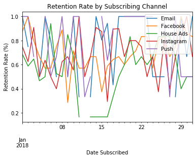

```python
 # Plot retention rate
retention_rate_df.plot()

plt.title('Retention Rate by Subscribing Channel')
plt.xlabel('Date Subscribed')
plt.ylabel('Retention Rate (%)')
plt.legend(loc= 'upper right',
labels = retention_rate_df.columns.values)
plt.show()
```

# Conversion rates by Age group

### Conversion function

```python
def conversion_rate(dataframe, column_names):
    # Total number of converted users
    column_conv = dataframe[dataframe['converted'] == True]\
                       .groupby(column_names)['user_id'].nunique()

    # Total number users
    column_total = dataframe.groupby(column_names)['user_id'].nunique()

    # Conversion rate
    conversion_rate = column_conv/column_total

    # Fill missing values with 0
    conversion_rate = conversion_rate.fillna(0)
    return conversion_rate
```

```python
# Calculate conversion rate by age_group
age_group_conv = conversion_rate(marketing, ['date_served', 'age_group'])
print(age_group_conv)
```

```
date_served  age_group
2018-01-01   0-18 years     0.155172
             19-24 years    0.196721
             24-30 years    0.105263
             30-36 years    0.040816
             36-45 years    0.042553
                              ...
2018-01-31   24-30 years    0.057692
             30-36 years    0.000000
             36-45 years    0.035088
             45-55 years    0.023256
             55+ years      0.026316
Name: user_id, Length: 217, dtype: float64
```

```python
# Unstack
age_group_df = pd.DataFrame(age_group_conv.unstack(level=1))
age_group_df
```

| age_group date_served | 0-18 years | 19-24 years | 24-30 years | 30-36 years | 36-45 years | 45-55 years | 55+ years |
| --- | --- | --- | --- | --- | --- | --- | --- |
| 2018-01-01 | 0.155172 | 0.196721 | 0.105263 | 0.040816 | 0.042553 | 0.022222 | 0.086957 |
| 2018-01-02 | 0.180328 | 0.164384 | 0.114754 | 0.040000 | 0.043478 | 0.043478 | 0.024390 |
| 2018-01-03 | 0.102041 | 0.208955 | 0.150943 | 0.042553 | 0.060000 | 0.047619 | 0.043478 |
| 2018-01-04 | 0.117647 | 0.200000 | 0.183673 | 0.045455 | 0.043478 | 0.061224 | 0.073171 |
| 2018-01-05 | 0.142857 | 0.250000 | 0.136364 | 0.090909 | 0.068182 | 0.046512 | 0.088889 |
| 2018-01-06 | 0.120000 | 0.188679 | 0.145833 | 0.078947 | 0.073171 | 0.068182 | 0.078947 |
| 2018-01-07 | 0.128205 | 0.220000 | 0.153846 | 0.100000 | 0.111111 | 0.128205 | 0.117647 |
| 2018-01-08 | 0.142857 | 0.196078 | 0.140000 | 0.069767 | 0.069767 | 0.051282 | 0.102564 |
| 2018-01-09 | 0.148936 | 0.200000 | 0.152174 | 0.090909 | 0.093023 | 0.068182 | 0.102564 |
| 2018-01-10 | 0.100000 | 0.216667 | 0.129630 | 0.068182 | 0.088889 | 0.090909 | 0.100000 |
| 2018-01-11 | 0.085106 | 0.187500 | 0.173913 | 0.000000 | 0.000000 | 0.055556 | 0.029412 |
| 2018-01-12 | 0.071429 | 0.226415 | 0.076923 | 0.075000 | 0.000000 | 0.000000 | 0.045455 |
| 2018-01-13 | 0.105263 | 0.130435 | 0.113636 | 0.052632 | 0.100000 | 0.023256 | 0.052632 |
| 2018-01-14 | 0.136364 | 0.200000 | 0.071429 | 0.025000 | 0.025641 | 0.073171 | 0.000000 |
| 2018-01-15 | 0.131148 | 0.170543 | 0.158940 | 0.090909 | 0.061224 | 0.074468 | 0.035294 |
| 2018-01-16 | 0.338462 | 0.371429 | 0.408451 | 0.109091 | 0.095238 | 0.130435 | 0.153846 |
| 2018-01-17 | 0.244898 | 0.315789 | 0.220339 | 0.224490 | 0.196721 | 0.156863 | 0.162791 |
| 2018-01-18 | 0.061224 | 0.244898 | 0.119048 | 0.020408 | 0.024390 | 0.074074 | 0.088235 |
| 2018-01-19 | 0.050000 | 0.060000 | 0.119048 | 0.050000 | 0.020833 | 0.071429 | 0.046512 |
| 2018-01-20 | 0.089286 | 0.095238 | 0.085106 | 0.075000 | 0.048780 | 0.000000 | 0.078947 |
| 2018-01-21 | 0.131579 | 0.113636 | 0.133333 | 0.029412 | 0.074074 | 0.074074 | 0.034483 |
| 2018-01-22 | 0.103448 | 0.242424 | 0.117647 | 0.000000 | 0.035714 | 0.150000 | 0.176471 |
| 2018-01-23 | 0.090909 | 0.103448 | 0.218750 | 0.125000 | 0.052632 | 0.038462 | 0.200000 |
| 2018-01-24 | 0.228571 | 0.178571 | 0.161290 | 0.000000 | 0.093750 | 0.000000 | 0.055556 |
| 2018-01-25 | 0.120000 | 0.305556 | 0.240000 | 0.000000 | 0.000000 | 0.093750 | 0.000000 |
| 2018-01-26 | 0.111111 | 0.187500 | 0.205128 | 0.000000 | 0.000000 | 0.000000 | 0.093750 |
| 2018-01-27 | 0.125000 | 0.069767 | 0.086957 | 0.065217 | 0.025641 | 0.022222 | 0.026316 |
| 2018-01-28 | 0.066667 | 0.156250 | 0.119048 | 0.000000 | 0.042553 | 0.000000 | 0.000000 |
| 2018-01-29 | 0.020833 | 0.106383 | 0.171875 | 0.000000 | 0.000000 | 0.041667 | 0.000000 |
| 2018-01-30 | 0.104167 | 0.061224 | 0.088889 | 0.052632 | 0.048780 | 0.024390 | 0.081081 |
| 2018-01-31 | 0.102041 | 0.105263 | 0.057692 | 0.000000 | 0.035088 | 0.023256 | 0.026316 |

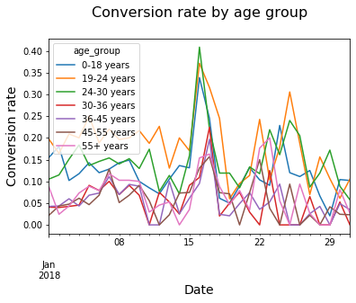

```python
# Visualize conversion by age_group
age_group_df.plot()
plt.title('Conversion rate by age group\n', size = 16)
plt.ylabel('Conversion rate', size = 14)
plt.xlabel('Date', size = 14)
plt.show()
```

### Plotting function

[figure not shown]

```python
def plotting_conv(dataframe):
    for column in dataframe:
        # Plot column by dataframe's index
        plt.plot(dataframe.index, dataframe[column])
        plt.title('Daily ' + str(column) + ' conversion rate\n',
                  size = 16)
        plt.ylabel('Conversion rate', size = 14)
        plt.xlabel('Date', size = 14)
        # Show plot
        plt.show()
        plt.clf()
```

# Daily conversion rate by marketing channel

```python
# Calculate conversion rate by date served and channel
daily_conv_channel = conversion_rate(marketing,['date_served', 'marketing_channel'])

print(daily_conv_channel.head())
```

```
date_served  marketing_channel
2018-01-01   Email                1.000000
             Facebook             0.117647
             House Ads            0.084656
             Instagram            0.106667
             Push                 0.083333
Name: user_id, dtype: float64
```

House and Push have low conversion rates. Why?

```python
# Calculate conversion rate by date served and channel
daily_conv_channel = conversion_rate(marketing, ['date_served', 'marketing_channel'])

# Unstack daily_conv_channel and convert it to a DataFrame
daily_conv_channel = pd.DataFrame(daily_conv_channel.unstack(level = 1))
daily_conv_channel
```

| marketing_channel date_served | Email | Facebook | House Ads | Instagram | Push |
| --- | --- | --- | --- | --- | --- |
| 2018-01-01 | 1.000000 | 0.117647 | 0.084656 | 0.106667 | 0.083333 |
| 2018-01-02 | 1.000000 | 0.098361 | 0.077982 | 0.129032 | 0.055556 |
| 2018-01-03 | 0.000000 | 0.080645 | 0.088542 | 0.171875 | 0.083333 |
| 2018-01-04 | 0.500000 | 0.138462 | 0.089820 | 0.126984 | 0.058824 |
| 2018-01-05 | 1.000000 | 0.112903 | 0.126582 | 0.159420 | 0.027778 |
| 2018-01-06 | 0.600000 | 0.111111 | 0.111842 | 0.095238 | 0.068966 |
| 2018-01-07 | 1.000000 | 0.096154 | 0.145038 | 0.175439 | 0.088235 |
| 2018-01-08 | 1.000000 | 0.136364 | 0.103896 | 0.125000 | 0.064516 |
| 2018-01-09 | 0.500000 | 0.120690 | 0.127389 | 0.152542 | 0.054054 |
| 2018-01-10 | 0.500000 | 0.109375 | 0.124260 | 0.134328 | 0.028571 |
| 2018-01-11 | 0.666667 | 0.120690 | 0.038710 | 0.116667 | 0.085714 |
| 2018-01-12 | 0.500000 | 0.114754 | 0.027211 | 0.142857 | 0.083333 |
| 2018-01-13 | 1.000000 | 0.142857 | 0.040541 | 0.096774 | 0.066667 |
| 2018-01-14 | 1.000000 | 0.105263 | 0.039735 | 0.171875 | 0.058824 |
| 2018-01-15 | 0.154791 | 0.119403 | 0.029268 | 0.125000 | 0.055556 |
| 2018-01-16 | 0.905660 | 0.250000 | 0.038710 | 0.239437 | 0.261905 |
| 2018-01-17 | 0.914286 | 0.202899 | 0.040816 | 0.246753 | 0.232558 |
| 2018-01-18 | 0.750000 | 0.134328 | 0.039474 | 0.161290 | 0.030303 |
| 2018-01-19 | 0.000000 | 0.080645 | 0.033784 | 0.093750 | 0.062500 |
| 2018-01-20 | 1.000000 | 0.092308 | 0.040000 | 0.080645 | 0.055556 |
| 2018-01-21 | 0.500000 | 0.142857 | 0.044248 | 0.104167 | 0.100000 |
| 2018-01-22 | 1.000000 | 0.153846 | 0.070588 | 0.210526 | 0.055556 |
| 2018-01-23 | 1.000000 | 0.176471 | 0.058824 | 0.166667 | 0.125000 |
| 2018-01-24 | 0.500000 | 0.179487 | 0.062500 | 0.171429 | 0.105263 |
| 2018-01-25 | 1.000000 | 0.142857 | 0.064516 | 0.205128 | 0.125000 |
| 2018-01-26 | 1.000000 | 0.142857 | 0.052632 | 0.119048 | 0.045455 |
| 2018-01-27 | 1.000000 | 0.090909 | 0.036145 | 0.081967 | 0.088235 |
| 2018-01-28 | 0.666667 | 0.119403 | 0.036810 | 0.049180 | 0.029412 |
| 2018-01-29 | 0.500000 | 0.080645 | 0.030488 | 0.095238 | 0.058824 |
| 2018-01-30 | 1.000000 | 0.109375 | 0.036585 | 0.050847 | 0.060606 |
| 2018-01-31 | 1.000000 | 0.078947 | 0.038217 | 0.041096 | 0.052632 |

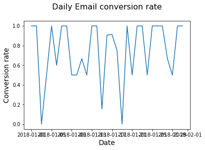

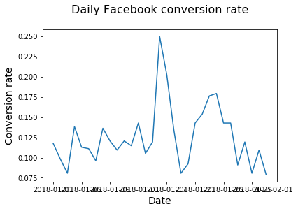

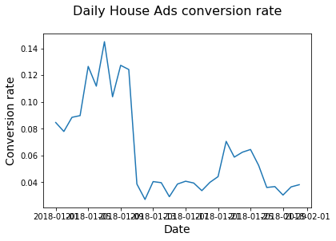

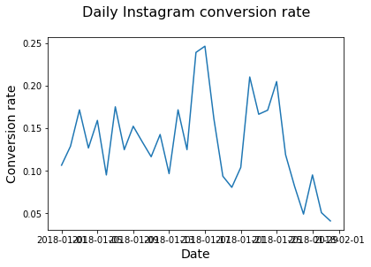

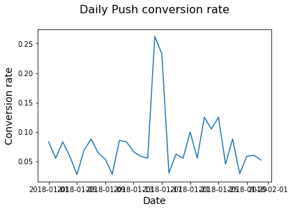

```python
# Plot results of daily_conv_channel
plotting_conv(daily_conv_channel)
```

# Analyzing House ads low conversion rate

Now that we have confirmed that house ads conversion has been down since January 11, we will try to identify potential causes for the decrease.

## by Day of Week

```python
# Add day of week column to marketing
marketing['DoW_served'] = marketing['date_served'].dt.dayofweek
marketing.columns
marketing.head(2)
marketing['DoW'].value_counts()
marketing['DoW_served'].value_counts()

# Calculate conversion rate by day of week
DoW_conversion = conversion_rate(marketing, ['DoW_served', 'marketing_channel'])
DoW_conversion.head()

# Unstack channels
DoW_df = pd.DataFrame(DoW_conversion.unstack(level=1))
DoW_df
```

| marketing_channel DoW_served | Email | Facebook | House Ads | Instagram | Push |
| --- | --- | --- | --- | --- | --- |
| 0.0 | 0.162621 | 0.119601 | 0.062660 | 0.122517 | 0.064516 |
| 1.0 | 0.906250 | 0.147887 | 0.070312 | 0.151943 | 0.115854 |
| 2.0 | 0.837209 | 0.127036 | 0.075269 | 0.150160 | 0.105882 |
| 3.0 | 0.727273 | 0.133333 | 0.059034 | 0.143498 | 0.067797 |
| 4.0 | 0.666667 | 0.110132 | 0.062278 | 0.129870 | 0.055556 |
| 5.0 | 0.818182 | 0.109375 | 0.057566 | 0.088710 | 0.069767 |
| 6.0 | 0.750000 | 0.116071 | 0.065217 | 0.127193 | 0.065574 |

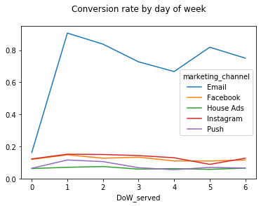

```python
# Plot conversion rate by day of week
DoW_df.plot()
plt.title('Conversion rate by day of week\n')
plt.ylim(0)
plt.show()
```

We can rule out natural fluctuations across the day of the week. Perhaps we can take a look at conversion by language over time. Maybe the new marketing campaign does not apply broadly across different cultures.

## by Language

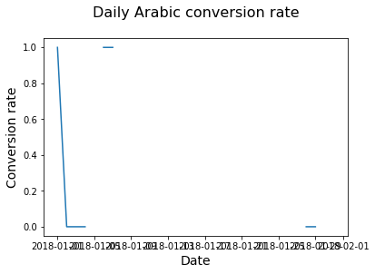

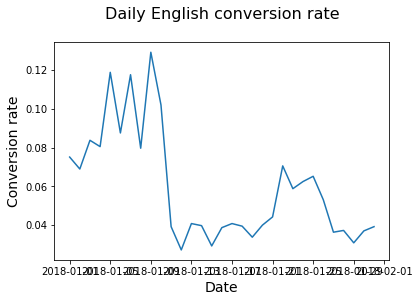

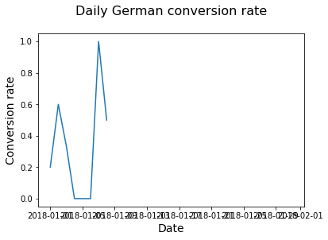

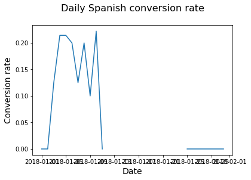

```python
# Isolate the rows where marketing channel is House Ads
marketing.head()
house_ads = marketing[marketing['marketing_channel'] == 'House Ads']
house_ads.head()

# Calculate conversion by date served, and language displayed
conv_lang_channel = conversion_rate(house_ads, ['date_served', 'language_displayed'])
conv_lang_channel
# Unstack conv_lang_channel
conv_lang_df = pd.DataFrame(conv_lang_channel.unstack(level=1))

# Use your plotting function to display results
plotting_conv(conv_lang_df)
```

There is a pattern around different language preferences that may have affected house ads conversion rate.

## Creating a DataFrame for house ads by language

```python
# Add new column is_correct_lang
house_ads['is_correct_lang'] = np.where(
    house_ads['language_preferred'] == house_ads['language_displayed'],
    'Yes',  'No')

house_ads['is_correct_lang'].value_counts()
```

```
Yes    4280
No      453
Name: is_correct_lang, dtype: int64
```

```python
# Groupby date_served and is_correct_lang
language_check = house_ads.groupby(['date_served','is_correct_lang'])['is_correct_lang'].count()

# Unstack language_check and fill missing values with 0's
language_check_df = pd.DataFrame(language_check.unstack(level=1)).fillna(0)

print(language_check_df)
```

```
is_correct_lang    No    Yes
date_served
2018-01-01        2.0  189.0
2018-01-02        3.0  247.0
2018-01-03        0.0  220.0
2018-01-04        0.0  168.0
2018-01-05        0.0  160.0
2018-01-06        1.0  151.0
2018-01-07        2.0  130.0
2018-01-08        0.0  154.0
2018-01-09        0.0  157.0
2018-01-10        0.0  170.0
2018-01-11       20.0  135.0
2018-01-12       18.0  130.0
2018-01-13       26.0  122.0
2018-01-14       20.0  131.0
2018-01-15       16.0  192.0
2018-01-16       28.0  127.0
2018-01-17       21.0  127.0
2018-01-18       31.0  121.0
2018-01-19       22.0  127.0
2018-01-20       28.0  124.0
2018-01-21       14.0  100.0
2018-01-22       13.0   72.0
2018-01-23       16.0   69.0
2018-01-24       13.0   83.0
2018-01-25       19.0   74.0
2018-01-26       24.0   92.0
2018-01-27       18.0  149.0
2018-01-28       28.0  136.0
2018-01-29       24.0  142.0
2018-01-30       23.0  145.0
2018-01-31       23.0  135.0
```

# Confirming house ads error

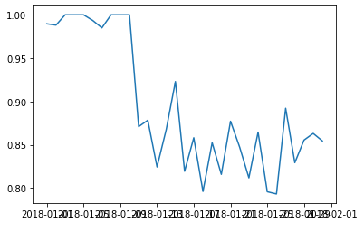

```python
language_check_df['pct'] = language_check_df['Yes']/language_check_df.sum(axis=1) #row sumbbb

plt.plot(language_check_df.index.values, language_check_df['pct'])
plt.show()
```

# Setting up conversion indexes

We need to know how many subscribers we lost as a result of this bug.

```python
#pre-error conversion rate
house_ads_bug = house_ads[house_ads['date_served'] < '2018-01-11']
lang_conv = conversion_rate(house_ads_bug, ['language_displayed'])

# Index other language conversion rate against English
spanish_index = lang_conv['Spanish']/lang_conv['English']
arabic_index = lang_conv['Arabic']/lang_conv['English']
german_index = lang_conv['German']/lang_conv['English']

print("Spanish index:", spanish_index)
print("Arabic index:", arabic_index)
print("German index:", german_index)
```

```
Spanish index: 1.681924882629108
Arabic index: 5.045774647887324
German index: 4.485133020344287
```

```python
# Group house_ads by date and language
converted = house_ads.groupby(['date_served', 'language_preferred']).agg({'user_id':'nunique','converted':'sum'})

# Unstack
converted = pd.DataFrame(converted.unstack(level=1))
converted
```

| language_preferred date_served | user_id Arabic | user_id English | user_id German | user_id Spanish | converted Arabic | converted English | converted German | converted Spanish |
| --- | --- | --- | --- | --- | --- | --- | --- | --- |
| 2018-01-01 | 2.0 | 171.0 | 5.0 | 11.0 | 2 | 13 | 1 | 0 |
| 2018-01-02 | 3.0 | 200.0 | 5.0 | 10.0 | 0 | 14 | 3 | 0 |
| 2018-01-03 | 2.0 | 179.0 | 3.0 | 8.0 | 0 | 15 | 1 | 1 |
| 2018-01-04 | 2.0 | 149.0 | 2.0 | 14.0 | 0 | 12 | 0 | 3 |
| 2018-01-05 | NaN | 143.0 | 1.0 | 14.0 | NaN | 17 | False | 3 |
| 2018-01-06 | 3.0 | 136.0 | 2.0 | 11.0 | 3 | 12 | 0 | 2 |
| 2018-01-07 | 2.0 | 117.0 | 2.0 | 10.0 | 2 | 14 | 2 | 1 |
| 2018-01-08 | NaN | 138.0 | 6.0 | 10.0 | NaN | 11 | 3 | 2 |
| 2018-01-09 | NaN | 147.0 | NaN | 10.0 | NaN | 19 | NaN | 1 |
| 2018-01-10 | NaN | 147.0 | 4.0 | 18.0 | NaN | 15 | 2 | 4 |
| 2018-01-11 | 7.0 | 133.0 | 2.0 | 13.0 | 0 | 6 | 0 | 0 |
| 2018-01-12 | 3.0 | 129.0 | 4.0 | 11.0 | 0 | 3 | 0 | 1 |
| 2018-01-13 | 6.0 | 121.0 | 5.0 | 16.0 | 0 | 5 | 1 | 0 |
| 2018-01-14 | 5.0 | 131.0 | 3.0 | 12.0 | 0 | 6 | 0 | 0 |
| 2018-01-15 | 2.0 | 189.0 | 4.0 | 10.0 | 0 | 6 | 0 | 0 |
| 2018-01-16 | 7.0 | 127.0 | 4.0 | 17.0 | 0 | 6 | 0 | 0 |
| 2018-01-17 | 2.0 | 126.0 | 3.0 | 16.0 | 0 | 2 | 0 | 4 |
| 2018-01-18 | 7.0 | 121.0 | 6.0 | 18.0 | 0 | 5 | 1 | 0 |
| 2018-01-19 | 5.0 | 126.0 | 5.0 | 12.0 | 1 | 4 | 0 | 0 |
| 2018-01-20 | 6.0 | 124.0 | 6.0 | 14.0 | 1 | 4 | 1 | 0 |
| 2018-01-21 | 1.0 | 99.0 | 4.0 | 9.0 | False | 5 | 0 | 0 |
| 2018-01-22 | 2.0 | 72.0 | 3.0 | 8.0 | 1 | 4 | 1 | 0 |
| 2018-01-23 | 3.0 | 69.0 | 4.0 | 9.0 | 0 | 5 | 0 | 0 |
| 2018-01-24 | 2.0 | 83.0 | 3.0 | 8.0 | 0 | 6 | 0 | 0 |
| 2018-01-25 | 3.0 | 75.0 | 4.0 | 11.0 | 0 | 4 | 2 | 0 |
| 2018-01-26 | 6.0 | 89.0 | 3.0 | 16.0 | 0 | 4 | 0 | 2 |
| 2018-01-27 | 3.0 | 148.0 | 3.0 | 12.0 | 1 | 4 | 0 | 1 |
| 2018-01-28 | 5.0 | 134.0 | 3.0 | 21.0 | 0 | 4 | 0 | 2 |
| 2018-01-29 | 7.0 | 138.0 | 4.0 | 15.0 | 2 | 3 | 0 | 0 |
| 2018-01-30 | 4.0 | 139.0 | 3.0 | 18.0 | 0 | 4 | 0 | 2 |
| 2018-01-31 | 7.0 | 130.0 | 4.0 | 16.0 | 1 | 4 | 0 | 1 |

```python
# English conversion rate column for affected period
converted['english_conv_rate'] = converted.loc['2018-01-11':'2018-01-31'][('converted','English')]
converted['english_conv_rate']

#  expected conversion rates for each language
converted['expected_spanish_rate'] = converted['english_conv_rate']*spanish_index
converted['expected_arabic_rate'] = converted['english_conv_rate']*arabic_index
converted['expected_german_rate'] = converted['english_conv_rate']*german_index

# Multiply number of users by the expected conversion rate
converted['expected_spanish_conv'] = converted['expected_spanish_rate']/100*converted[('user_id','Spanish')]
converted['expected_arabic_conv'] = converted['expected_arabic_rate']/100*converted[('user_id','Arabic')]
converted['expected_german_conv'] = converted['expected_german_rate']/100*converted[('user_id','German')]
```

```python
# slice only the relevant dates
converted = converted.loc['2018-01-11':'2018-01-31']

# Sum expected subscribers for each language
expected_subs = converted['expected_spanish_conv'].sum() + converted['expected_arabic_conv'].sum() + converted['expected_german_conv'].sum()

#  how many subscribers we actually got
actual_subs = converted[('converted','Spanish')].sum() + converted[('converted','Arabic')].sum() + converted[('converted','German')].sum()

# how many subscribers we got despite the bug
lost_subs = expected_subs - actual_subs
print('Subscirbers lost',lost_subs)
```

```
Subscirbers lost 32.144143192488265
```

# A/B Testing on e-mails

```python
marketing.head()
```

|  | user_id | date_served | marketing_channel | variant | converted | language_displayed | language_preferred | age_group | date_subscribed | date_canceled | subscribing_channel | is_retained | DoW | DoW_served |
| --- | --- | --- | --- | --- | --- | --- | --- | --- | --- | --- | --- | --- | --- | --- |
| 0 | a100000029 | 2018-01-01 | House Ads | personalization | True | English | English | 0-18 years | 2018-01-01 | NaT | House Ads | True | 0.0 | 0.0 |
| 1 | a100000030 | 2018-01-01 | House Ads | personalization | True | English | English | 19-24 years | 2018-01-01 | NaT | House Ads | True | 0.0 | 0.0 |
| 2 | a100000031 | 2018-01-01 | House Ads | personalization | True | English | English | 24-30 years | 2018-01-01 | NaT | House Ads | True | 0.0 | 0.0 |
| 3 | a100000032 | 2018-01-01 | House Ads | personalization | True | English | English | 30-36 years | 2018-01-01 | NaT | House Ads | True | 0.0 | 0.0 |
| 4 | a100000033 | 2018-01-01 | House Ads | personalization | True | English | English | 36-45 years | 2018-01-01 | NaT | House Ads | True | 0.0 | 0.0 |

## Test allocation

Half the emails sent out were generic upsells to the product while the other half contained personalized messaging around the users’ usage of the site.

```python
# Subset email DataFrame
email = marketing[marketing['marketing_channel'] == 'Email']
email.head(2)
email.columns

email['variant'].value_counts()
```

```
personalization    291
control            274
Name: variant, dtype: int64
```

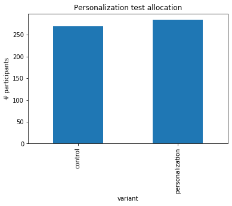

```python
# Group the email DataFrame by variant
alloc = email.groupby(['variant'])['user_id'].nunique()
alloc

# test allocation
alloc.plot(kind='bar')
plt.title('Personalization test allocation')
plt.ylabel('# participants')
plt.show()
```

Users were allocated equally to the test and control groups.

## Comparing conversion rates for control and personalization

Conversion rate will be our key metric. It is highly important that we evaluate whether or not conversion was higher in the personalization treatment compared with the control as it is part of evaluating the success of an A/B test.

```python
# Group marketing by user_id and variant
subscribers = email.groupby(['user_id', 'variant'])['converted'].max()

subscribers_df = pd.DataFrame(subscribers.unstack(level=1))
subscribers_df.head()
```

| variant user_id | control | personalization |
| --- | --- | --- |
| a100000526 | NaN | True |
| a100000530 | NaN | True |
| a100000534 | NaN | False |
| a100000538 | NaN | True |
| a100000542 | NaN | True |

```python
# Drop missing values from the control column
control = subscribers_df['control'].dropna()
control
```

```
user_id
a100000687    False
a100000688     True
a100000689     True
a100000690     True
a100000691     True
              ...
a100007288     True
a100007289     True
a100007290     True
a100007291     True
a100007293     True
Name: control, Length: 270, dtype: object
```

```python
# Drop missing values from the personalization column
personalization = subscribers_df['personalization'].dropna()
personalization
```

```
user_id
a100000526     True
a100000530     True
a100000534    False
a100000538     True
a100000542     True
              ...
a100007273     True
a100007274     True
a100007275     True
a100007276     True
a100007277     True
Name: personalization, Length: 284, dtype: object
```

```python
print('Control conversion rate:', np.mean(control))
print('Personalization conversion rate:',np.mean(personalization))
```

```
Control conversion rate: 0.2814814814814815
Personalization conversion rate: 0.3908450704225352
```

Conversion rate is higher in personalized emails.

## Lift & significance testing

Lift is the percent difference between the control and treatment.

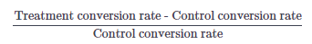

In this exercise, you will create a function to automate the process of calculating lift. Many marketing teams run tests constantly. The more that you can automate the parts of the process that occur within every test, the more time you will have to do more interesting analyses.

```python
def lift(a,b):
    # Calcuate the mean of a and b
    a_mean = np.mean(a)
    b_mean = np.mean(b)

    # Calculate the lift using a_mean and b_mean
    lift = (b_mean-a_mean)/a_mean

    return str(round(lift*100, 2)) + '%'

#lift() with control and personalization
print(lift(control, personalization))
```

```
38.85%
```

There is a 38.85% difference in conversion rate between personalized and controlled emails. The personalization variant outperformed the control.

## Evaluating statistical significance

It is important to determine whether the result is statistically significant. Statistical significance is vital to understanding whether a test showed a positive result by chance or if it is reflective of a true difference between the variants. This will enable marketing teams to make an informed choice about whether to roll out the feature or not.

We can use T-test for the means of two independent samples of scores, if we observe two independent samples from the same or different population.

```python
from scipy.stats import ttest_ind
t = ttest_ind(control, personalization)
print(t)
```

```
Ttest_indResult(statistic=-2.7343299447505074, pvalue=0.006451487844694175)
```

## A/B test segmenting function

automated function

```python
def ab_segmentation(segment):
  # loop for each segment in marketing
  for subsegment in np.unique(marketing[segment].values):
      print(subsegment)

      # Limit marketing to email and subsegment
      email = marketing[(marketing['marketing_channel'] == 'Email') & (marketing[segment] == subsegment)]

      subscribers = email.groupby(['user_id', 'variant'])['converted'].max()
      subscribers = pd.DataFrame(subscribers.unstack(level=1))
      control = subscribers['control'].dropna()
      personalization = subscribers['personalization'].dropna()

      print('lift:', lift(control, personalization))
      print('t-statistic:',ttest_ind(control, personalization), '\n\n')
```

```python
# ab_segmentation on language displayed
ab_segmentation('language_displayed')
```

```
Arabic
lift: 50.0%
t-statistic: Ttest_indResult(statistic=-0.5773502691896255, pvalue=0.5795840000000001)


English
lift: 39.0%
t-statistic: Ttest_indResult(statistic=-2.2183598646203166, pvalue=0.026991701290720815)


German
lift: -1.62%
t-statistic: Ttest_indResult(statistic=0.1910083418078718, pvalue=0.8494394170062678)


Spanish
lift: 166.67%
t-statistic: Ttest_indResult(statistic=-2.3570226039551585, pvalue=0.040156718110477524)
```

```python
ab_segmentation('age_group')
```

```
0-18 years
lift: 121.4%
t-statistic: Ttest_indResult(statistic=-2.966044912142211, pvalue=0.0038724494391297226)


19-24 years
lift: 106.24%
t-statistic: Ttest_indResult(statistic=-3.03179438478667, pvalue=0.0030623836114689134)


24-30 years
lift: 161.19%
t-statistic: Ttest_indResult(statistic=-3.861539544326876, pvalue=0.00018743381094867337)


30-36 years
lift: -100.0%
t-statistic: Ttest_indResult(statistic=3.1859064644147996, pvalue=0.0023238487431765137)


36-45 years
lift: -85.23%
t-statistic: Ttest_indResult(statistic=2.4317901279318503, pvalue=0.01797568600978829)


45-55 years
lift: -72.22%
t-statistic: Ttest_indResult(statistic=2.065499127317933, pvalue=0.043062339688201196)


55+ years
lift: -100.0%
t-statistic: Ttest_indResult(statistic=3.3265654564203397, pvalue=0.0016358623456360435)
```